# **ANALISI DEGLI ESOPIANETI SCOPERTI TRA IL 1992 E IL 2017**

# **INTRODUZIONE**

## **COSA SONO GLI ESOPIANETI?**

- Sono corpi celesti che orbitano attorno a stelle diverse dal nostro Sole.
- Le caratteristiche di ciascun esopianeta variano molto da un pianeta all'altro.

## **PERCHE' HO SCELTO QUESTO TEMA?**

- Interesse personale e possibile carriera futura

## **LE DOMANDE CHE MI SONO POSTA**

- Quanti esopianeti sono stati scoperti ogni anno e con quale metodo?
- In che tipo di sistemi abitano?
- Che caratteristiche hanno rispetto alla Terra?
- Che caratterestiche hanno le stelle attorno alle quali ruotano?

## **IL DATASET**

- Fonte: https://www.kaggle.com/datasets/mrisdal/open-exoplanet-catalogue
- Descrizione: 3582 esopianeti scoperti tra il 1992 e il 2017.

## **COSTANTI USATE**

- Massa di Giove: 1.8991766e+27 kg
- Massa del Sole: 1.9891e+30 kg
- Raggio di Giove: 69911000 m
- Raggio del Sole: 6.96e+08 m

# **ANALISI DEI DATI**

### **Quanti pianeti sono stati scoperti ogni anno?**

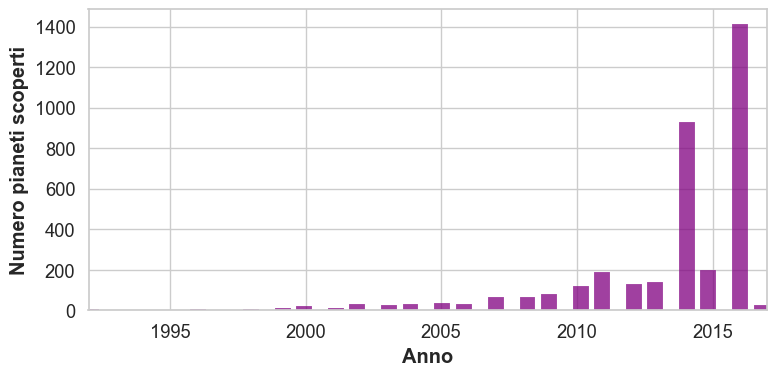

Zoom sull'intervallo temporale 1992-2000

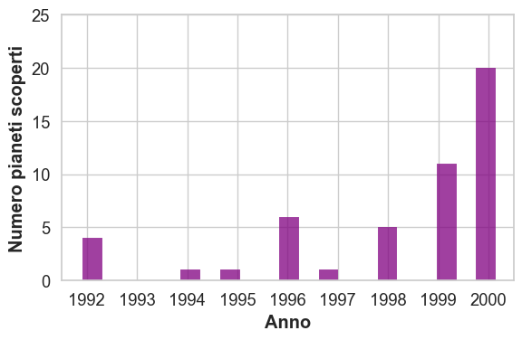

### **Quali metodi sono stati utilizzati maggiormente per trovare gli esopianeti?**

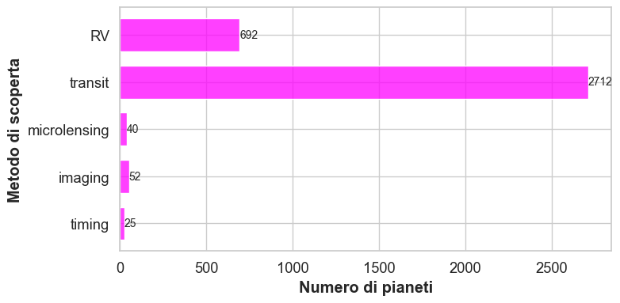

### **In che periodo sono stati utilizzati i vari metodi?**

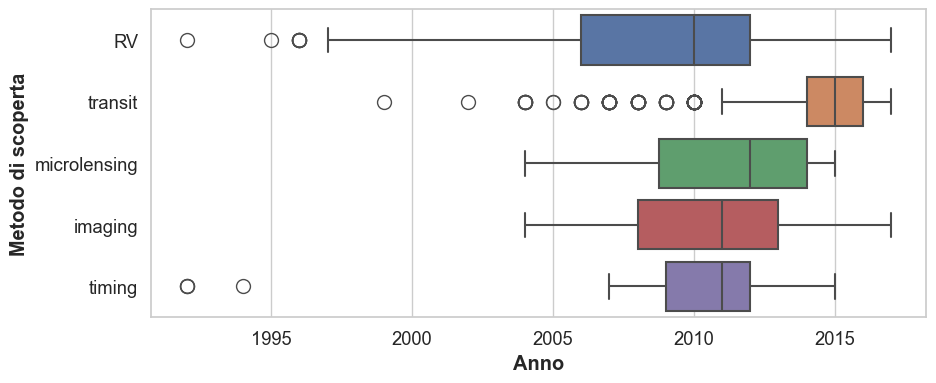

### **Quali sono i tipi di sistemi più diffusi?**

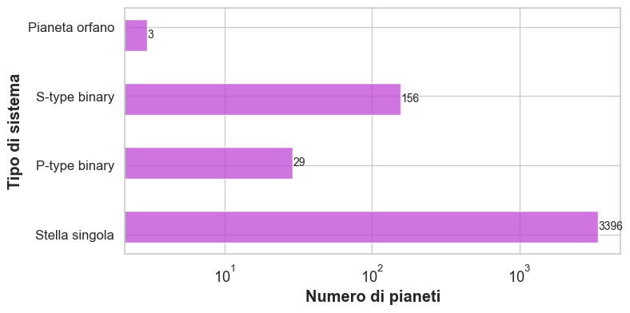

### **Grandezza degli esopianeti rispetto al tipo di sistema**

- Raggio di Giove: 69911000 m
- Raggio della Terra: 6378000 m
- Terra/Giove: 0,09

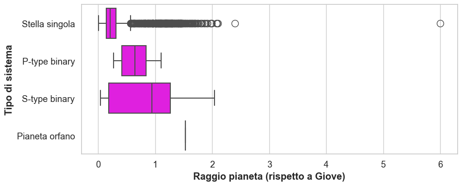

### **Temperatura degli esopianeti**

- Temperatura superficiale media terrestre: 288 K

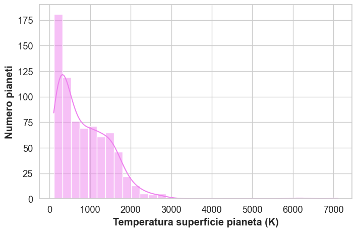

### **Correlazione tra raggio e massa delle stelle**

- Massa del Sole: 1.9891e+30 kg
- Raggio del Sole: 6.96e+08 m

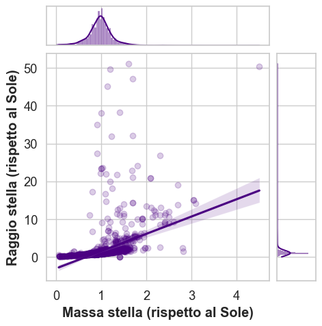

### **Correlazione tra massa e temperatura delle stelle**

- Massa del Sole: 1.9891e+30 kg
- Temperatura superficiale solare: 5772 K

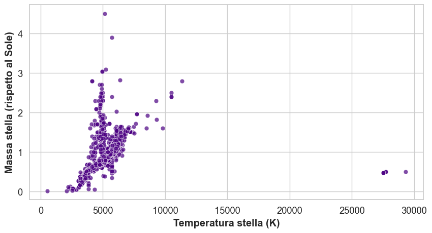

# **CONCLUSIONI**

- L'anno in cui sono stati individuati più esopianeti è il 2016.
- Il metodo più diffuso per individuarli è il metodo del transito.
- La maggior parte di essi orbita attorno a stelle singole.
- Le caratteristiche degli esopianeti variano enormemente in termini di dimensioni, massa, composizione e orbita.